# Relative cover analysis

Claudia Campanini

Load some basic libraries

```r
library(dplyr)
```

```r
library(ggplot2)
library(readxl)   # to import excel datasets
library(writexl) # to export df to excel files (write_xlsx)
library(here)
```

# 1 MEAN RELATIVE BENTHIC COVER BY CATEGORY

Load input file

```r
cov_df <- read_excel(here("Multi-taxa_data","PLITs","3-Clean_data","plits_ext_df.xlsx"))
str(cov_df)
```

```
## tibble [621 × 10] (S3: tbl_df/tbl/data.frame)
##  $ Category  : chr [1:621] "algae" "boulder" "hard_coral" "other" ...
##  $ Abs_cov   : num [1:621] 2230 48 0 0 156 122 60 7 0 2390 ...
##  $ Rel_cov   : num [1:621] 0.85 0.018 0 0 0.059 0.047 0.023 0.003 0 0.92 ...
##  $ Depth_rep : chr [1:621] "D1" "D1" "D1" "D1" ...
##  $ Site      : chr [1:621] "AW" "AW" "AW" "AW" ...
##  $ depth     : chr [1:621] "Deep" "Deep" "Deep" "Deep" ...
##  $ Transect  : chr [1:621] "AW_D1" "AW_D1" "AW_D1" "AW_D1" ...
##  $ Site_depth: chr [1:621] "AW_Deep" "AW_Deep" "AW_Deep" "AW_Deep" ...
##  $ Replicate : num [1:621] 1 1 1 1 1 1 1 1 1 2 ...
##  $ sd_rel_cov: num [1:621] 0.05 0.01 0.01 0 0.03 0.02 0.01 0.01 0 0.05 ...
```

## 1.1 PER SITE

Follow the link for explanation of dcast function https://seananderson.ca/2013/10/19/reshape/

```r
mean_rel_cov_site <- cov_df %>%
  group_by(Site, Category) %>%
  summarise(Mean_rel_cov=round(mean(Rel_cov),2))
library(reshape2) #needed for dcast function
mean_rel_cov_site <- dcast(mean_rel_cov_site, Site ~ Category)
mean_rel_cov_site <- mean_rel_cov_site %>%
  mutate(Pressure = case_when(Site == 'HI' |
                              Site == "S1" |
                              Site == "S2" ~ "Low",
                              Site == "ZP" |
                              Site == 'ZA' |
                              Site == "YO" |
                              Site == "MI" ~ "Medium",
                              Site == 'SK' |
                              Site == 'SN' |
                              Site == "AW" |
                              Site == "G1" |
                              Site == "G2"~ "High")
         )

mean_rel_cov_site$Site<-ordered(mean_rel_cov_site$Site,levels=c("HI", "S1", "S2", "ZP", "ZA", "YO", "MI","SK", "SN", "AW", "G1", "G2"))

mean_rel_cov_site <- mean_rel_cov_site[,c(1,11,2:10)] #re-ordering columns

mean_rel_cov_site$Pressure <- ordered(mean_rel_cov_site$Pressure,
                                      levels
                                      =c("Low","Medium","High"))

mean_rel_cov_site <- mean_rel_cov_site[order(mean_rel_cov_site$Site),]
mean_rel_cov_site
```

```
##    Site Pressure algae boulder hard_coral other rubble sand soft_coral unknown
## 4    HI      Low  0.38    0.01       0.55  0.00   0.00 0.00       0.02    0.02
## 6    S1      Low  0.59    0.00       0.33  0.00   0.02 0.05       0.00    0.01
## 7    S2      Low  0.48    0.00       0.30  0.02   0.13 0.07       0.00    0.00
## 12   ZP   Medium  0.71    0.00       0.26  0.00   0.00 0.00       0.01    0.01
## 11   ZA   Medium  0.70    0.04       0.20  0.00   0.00 0.01       0.02    0.02
## 10   YO   Medium  0.54    0.01       0.34  0.00   0.00 0.02       0.04    0.03
## 5    MI   Medium  0.51    0.00       0.16  0.00   0.00 0.00       0.27    0.01
## 8    SK     High  0.79    0.00       0.17  0.00   0.00 0.01       0.00    0.03
## 9    SN     High  0.52    0.10       0.06  0.00   0.00 0.04       0.24    0.03
## 1    AW     High  0.90    0.01       0.04  0.00   0.02 0.02       0.00    0.01
## 2    G1     High  0.67    0.00       0.16  0.00   0.00 0.02       0.09    0.02
## 3    G2     High  0.28    0.00       0.07  0.00   0.00 0.00       0.60    0.00
##    zoanthids
## 4       0.00
## 6       0.00
## 7       0.00
## 12      0.00
## 11      0.01
## 10      0.02
## 5       0.04
## 8       0.00
## 9       0.01
## 1       0.00
## 2       0.04
## 3       0.04
```

```r
write_xlsx(mean_rel_cov_site, here("Multi-taxa_data","PLITs","3-Clean_data","mean_rel_cov_site.xlsx"))
```

## 1.2 PER SITE WITHIN Depth

```r
mean_rel_cov_df <- cov_df %>%
  group_by(Site_depth, Category) %>%
  summarise(Mean_rel_cov=round(mean(Rel_cov),2))
Site_depth <- mean_rel_cov_df$Site_depth

library(tidyr) # needed for separate_wider_delim function
mean_rel_cov_df <- mean_rel_cov_df %>%
  separate_wider_delim(Site_depth, "_", names = c("Site", "Depth")) %>%
  mutate(Site_depth=Site_depth)

rm(Site_depth)

mean_rel_cov_df <-
  mean_rel_cov_df %>%
  mutate(Pressure = case_when(Site == "HI" |
                              Site == "S1" |
                              Site == "S2" ~ "Low",
                              Site == "ZP" |
                              Site == 'ZA' |
                              Site == "YO" |
                              Site == "MI" ~ "Medium",
                              Site == 'SK' |
                              Site == 'SN' |
                              Site == "AW" |
                              Site == "G1" |
                              Site == "G2"~ "High"
                              )
         )

mean_rel_cov_df$Site_depth <- as.factor(mean_rel_cov_df$Site_depth)

mean_rel_cov_df$Pressure <- ordered(mean_rel_cov_df$Pressure,
                                    levels=c("Low","Medium","High"))

mean_rel_cov_wide <- dcast(mean_rel_cov_df,
                           Site_depth + Pressure ~ Category,
                           value.var = "Mean_rel_cov")

mean_rel_cov_wide <- mean_rel_cov_wide[order(mean_rel_cov_wide$Site),]

mean_rel_cov_wide
```

```
##    Site_depth Pressure algae boulder hard_coral other rubble sand soft_coral
## 1     AW_Deep     High  0.90    0.01       0.01  0.00   0.03 0.03       0.01
## 2  AW_Shallow     High  0.91    0.01       0.06  0.00   0.01 0.01       0.00
## 3     G1_Deep     High  0.64    0.00       0.13  0.00   0.01 0.05       0.15
## 4  G1_Shallow     High  0.69    0.00       0.18  0.00   0.00 0.00       0.02
## 5     G2_Deep     High  0.42    0.00       0.14  0.00   0.00 0.00       0.35
## 6  G2_Shallow     High  0.14    0.00       0.00  0.00   0.00 0.00       0.86
## 7     HI_Deep      Low  0.35    0.01       0.58  0.00   0.00 0.01       0.02
## 8  HI_Shallow      Low  0.42    0.01       0.53  0.00   0.00 0.00       0.02
## 9     MI_Deep   Medium  0.32    0.00       0.20  0.00   0.00 0.00       0.42
## 10 MI_Shallow   Medium  0.71    0.01       0.12  0.00   0.00 0.00       0.13
## 11    S1_Deep      Low  0.57    0.00       0.35  0.00   0.03 0.05       0.00
## 12 S1_Shallow      Low  0.61    0.00       0.30  0.00   0.01 0.06       0.01
## 13    S2_Deep      Low  0.45    0.00       0.34  0.03   0.12 0.06       0.00
## 14 S2_Shallow      Low  0.51    0.01       0.26  0.00   0.14 0.07       0.00
```

[output cut: 33 more lines]

```r
write_xlsx(mean_rel_cov_site, here("Multi-taxa_data","PLITs","3-Clean_data","mean_rel_cov_Site_depth.xlsx"))
```

## 1.3 STACKED BARPLOTS

Load the color-blind-friendly palette with black:

```r
relcovPalette <- c("#009E73","#E69F00","#D55E00", "#56B4E9", "#F0E442", "#0072B2", "#CC79A7","#000000","#999999") #I changed the order compared to the original version
```

Stacked barplot of the mean relative benthic cover

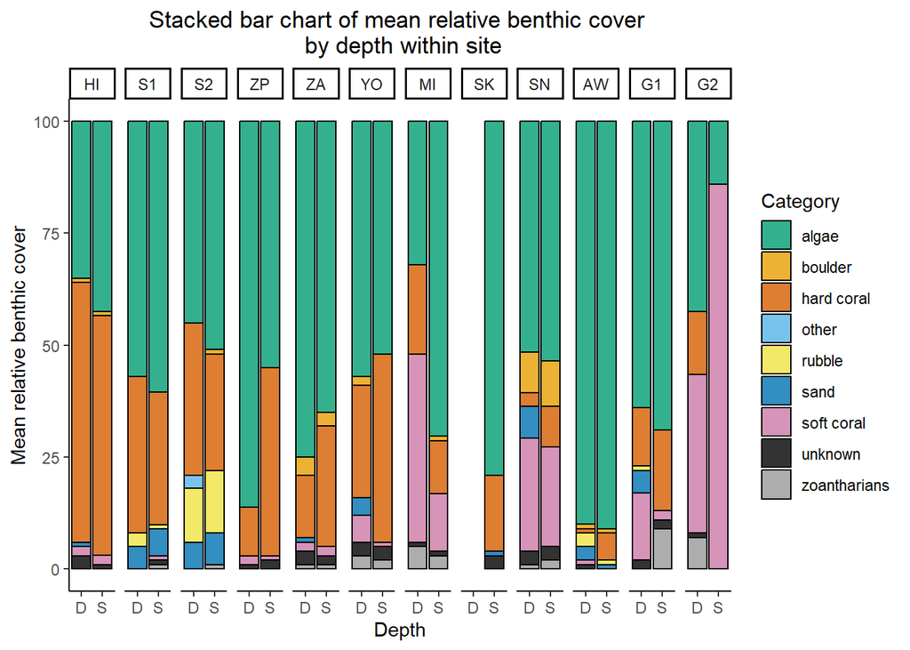

```r
mean_rel_cov_df <- mean_rel_cov_df %>%                               # Replacing values
  mutate(Depth = replace(Depth, Depth == "Deep", "D")) %>%                     # Replacing values
  mutate(Depth = replace(Depth, Depth == "Shallow", "S"))

mean_rel_cov_df$Site<-ordered(mean_rel_cov_df$Site,levels=c("HI", "S1", "S2", "ZP", "ZA", "YO", "MI","SK", "SN", "AW", "G1", "G2"))

ggplot(mean_rel_cov_df,
       aes(fill=Category, y=Mean_rel_cov, x=Depth, label=Mean_rel_cov)) +
  geom_bar(position="fill", stat="identity",alpha=.8, color = "black")+
  facet_grid(~ Site)+
  theme_classic()+
  labs(x="Depth",
       y="Mean relative benthic cover",
       title= "Stacked bar chart of mean relative benthic cover \n by depth within site")+
  theme(plot.title = element_text(hjust = 0.5))+
  scale_fill_manual(labels = c("algae",
                                "boulder",
                                "hard coral",
                                "other",
                                "rubble",
                                "sand",
                                "soft coral",
                                "unknown",
                                "zoantharians"), values=relcovPalette)+
  scale_y_continuous(limits = c(0, 1),
                     breaks = c(0, 0.25, 0.50, 0.75,1),
                     labels = c(0, 25, 50, 75,100))
```

```r
ggsave("relcov_stacked.tiff",
       units ="in", width = 5, height = 4, dpi = 300, compression = 'lzw',
       path = here("Multi-taxa_data","PLITs","4-Visualization_outputs"))

ggsave("relcov_stacked.png",
       units ="in", width = 5, height = 4, dpi = 300,
       path = here("Multi-taxa_data","PLITs","4-Visualization_outputs"))
```

## 1.4 STACKED BAR CHART BY PRESSURE

```r
mean_rel_cov_site <- cov_df %>%
  group_by(Site, Category) %>%
  summarise(Mean_rel_cov=round(mean(Rel_cov),2))
library(reshape2) #needed for dcast function
mean_rel_cov_site <- dcast(mean_rel_cov_site, Site ~ Category)
mean_rel_cov_site <- mean_rel_cov_site %>%
  mutate(Pressure = case_when(Site == 'HI' |
                              Site == "S1" |
                              Site == "S2" ~ "Low",
                              Site == "ZP" |
                              Site == 'ZA' |
                              Site == "YO" |
                              Site == "MI" ~ "Medium",
                              Site == 'SK' |
                              Site == 'SN' |
                              Site == "AW" |
                              Site == "G1" |
                              Site == "G2"~ "High")
         )

mean_rel_cov_site$Site<-ordered(mean_rel_cov_site$Site,levels=c("HI", "S1", "S2", "ZP", "ZA", "YO", "MI","SK", "SN", "AW", "G1", "G2"))

mean_rel_cov_site <- mean_rel_cov_site[,c(1,11,2:10)] #re-ordering columns

mean_rel_cov_site$Pressure <- ordered(mean_rel_cov_site$Pressure,
                                      levels
                                      =c("Low","Medium","High"))

mean_rel_cov_site <- mean_rel_cov_site[order(mean_rel_cov_site$Site),]
mean_rel_cov_site
```

```
##    Site Pressure algae boulder hard_coral other rubble sand soft_coral unknown
## 4    HI      Low  0.38    0.01       0.55  0.00   0.00 0.00       0.02    0.02
## 6    S1      Low  0.59    0.00       0.33  0.00   0.02 0.05       0.00    0.01
## 7    S2      Low  0.48    0.00       0.30  0.02   0.13 0.07       0.00    0.00
## 12   ZP   Medium  0.71    0.00       0.26  0.00   0.00 0.00       0.01    0.01
## 11   ZA   Medium  0.70    0.04       0.20  0.00   0.00 0.01       0.02    0.02
## 10   YO   Medium  0.54    0.01       0.34  0.00   0.00 0.02       0.04    0.03
## 5    MI   Medium  0.51    0.00       0.16  0.00   0.00 0.00       0.27    0.01
## 8    SK     High  0.79    0.00       0.17  0.00   0.00 0.01       0.00    0.03
## 9    SN     High  0.52    0.10       0.06  0.00   0.00 0.04       0.24    0.03
## 1    AW     High  0.90    0.01       0.04  0.00   0.02 0.02       0.00    0.01
## 2    G1     High  0.67    0.00       0.16  0.00   0.00 0.02       0.09    0.02
## 3    G2     High  0.28    0.00       0.07  0.00   0.00 0.00       0.60    0.00
##    zoanthids
## 4       0.00
## 6       0.00
## 7       0.00
## 12      0.00
## 11      0.01
## 10      0.02
## 5       0.04
## 8       0.00
## 9       0.01
## 1       0.00
## 2       0.04
## 3       0.04
```

```r
mean_rel_cov_pressure <- cov_df %>%
  mutate(Pressure = case_when(Site == 'HI' |
                              Site == "S1" |
                              Site == "S2" ~ "Low",
                              Site == "ZP" |
                              Site == 'ZA' |
                              Site == "YO" |
                              Site == "MI" ~ "Medium",
                              Site == 'SK' |
                              Site == 'SN' |
                              Site == "AW" |
                              Site == "G1" |
                              Site == "G2"~ "High"))

mean_rel_cov_pressure <- mean_rel_cov_pressure %>%
  group_by(Pressure, depth, Category) %>%
  summarise(Mean_rel_cov=round(mean(Rel_cov),2))
mean_rel_cov_pressure$Pressure <- ordered(mean_rel_cov_pressure$Pressure,levels
                                      =c("Low","Medium","High"))
```

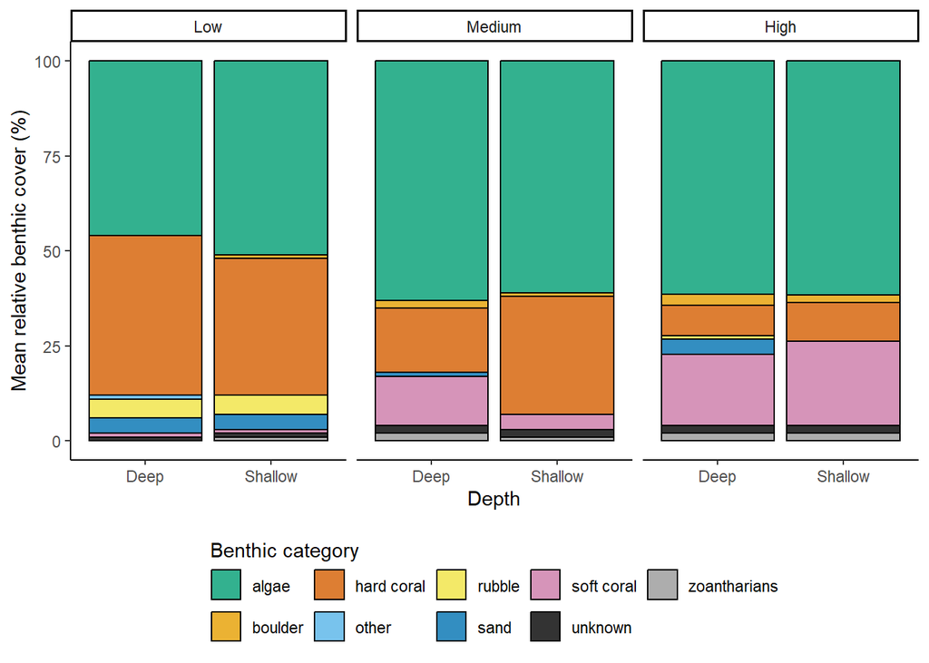

```r
ggplot(mean_rel_cov_pressure,
       aes(x=depth, y=Mean_rel_cov,
           fill=Category, label=Mean_rel_cov)) +
  geom_bar(position="fill",
           stat="identity",
           alpha=.8,
           color = "black")+
  facet_grid(~ Pressure)+
  theme_classic()+
  labs(x="Depth",
       y="Mean relative benthic cover (%)",
       fill="Benthic category")+
  theme(plot.title = element_text(hjust = 0.5),
        legend.position = "bottom")+
  guides(fill = guide_legend(title.position = "top"))+
  scale_fill_manual(labels = c("algae",
                                "boulder",
                                "hard coral",
                                "other",
                                "rubble",
                                "sand",
                                "soft coral",
                                "unknown",
                                "zoantharians"),
                    values=relcovPalette)+
  scale_y_continuous(limits = c(0, 1),
                     breaks = c(0, 0.25, 0.50, 0.75,1),
                     labels = c(0, 25, 50, 75,100)
                     )
```

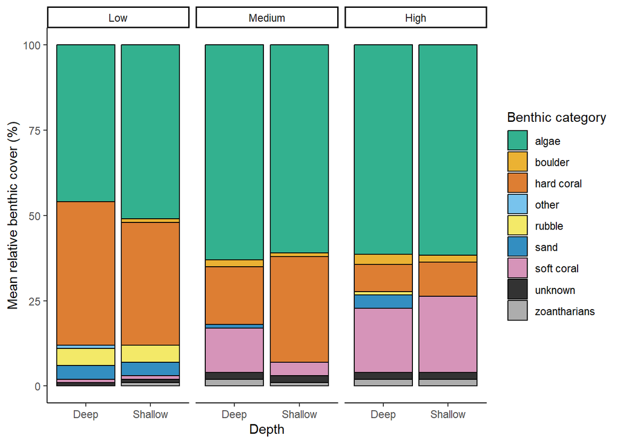

```r
ggplot(mean_rel_cov_pressure,
       aes(fill=Category, y=Mean_rel_cov, x=depth,
           label=Mean_rel_cov)) +
  geom_bar(position="fill",
           stat="identity",
           alpha=.8,
           color = "black")+
  facet_grid(~ Pressure)+
  theme_classic()+
  labs(x="Depth",
       y="Mean relative benthic cover (%)",
       fill="Benthic category")+
  theme(plot.title = element_text(hjust = 0.5))+
  scale_fill_manual(labels = c("algae",
                                "boulder",
                                "hard coral",
                                "other",
                                "rubble",
                                "sand",
                                "soft coral",
                                "unknown",
                                "zoantharians"),
                    values=relcovPalette)+
  scale_y_continuous(limits = c(0, 1),
                     breaks = c(0, 0.25, 0.50, 0.75,1),
                     labels = c(0, 25, 50, 75,100)
                     )
```

Export

```r
ggsave("relcov_stacked_pressure.tiff",
       units ="in", width = 5, height = 6, dpi = 300, compression = 'lzw',
       path = here("Multi-taxa_data","PLITs","4-Visualization_outputs"))
```

# 2 nMDS

Load packages

```r
library(here)
library(vegan)
library(htmltools)
library(MASS)
```

```r
library(dplyr)
library(readxl)   # to import excel datasets
library(ggplot2)
```

## 2.1 Format the data

Load relative benthic cover data

```r
#Relative benthic cover dataframe

cov_df <- read_excel(here("Multi-taxa_data","PLITs","3-Clean_data","Rel_cov_input.xlsx"))
str(cov_df)
```

```
## tibble [69 × 24] (S3: tbl_df/tbl/data.frame)
##  $ Transect  : chr [1:69] "AW_D1" "AW_D2" "AW_D3" "AW_S1" ...
##  $ Site      : chr [1:69] "AW" "AW" "AW" "AW" ...
##  $ Depth_rep : chr [1:69] "D1" "D2" "D3" "S1" ...
##  $ depth     : chr [1:69] "Deep" "Deep" "Deep" "Shallow" ...
##  $ Site_depth: chr [1:69] "AW_Deep" "AW_Deep" "AW_Deep" "AW_Shallow" ...
##  $ Replicate : chr [1:69] "1" "2" "3" "1" ...
##  $ algae     : num [1:69] 0.85 0.92 0.934 0.953 0.874 0.899 0.497 0.691 0.734 0.8 ...
##  $ boulder   : num [1:69] 0.018 0 0.01 0 0.023 0 0 0 0 0 ...
##  $ hard_coral: num [1:69] 0 0.018 0.026 0.023 0.073 0.075 0.104 0.143 0.152 0.167 ...
##  $ other     : num [1:69] 0 0.001 0 0 0 0 0 0 0 0 ...
##  $ rubble    : num [1:69] 0.059 0.004 0.014 0.019 0.001 0.01 0.005 0.012 0 0 ...
##  $ sand      : num [1:69] 0.047 0.042 0.006 0.003 0.024 0.008 0.096 0.036 0.014 0 ...
##  $ soft_coral: num [1:69] 0.023 0.001 0 0 0.001 0.002 0.276 0.107 0.077 0 ...
##  $ unknown   : num [1:69] 0.003 0.014 0.009 0.001 0.004 0.003 0.023 0.01 0.024 0.033 ...
##  $ zoanthids : num [1:69] 0 0 0 0 0 0.003 0 0 0 0 ...
##  $ sd_alg    : num [1:69] 0.05 0.05 0.05 0.04 0.04 0.04 0.13 0.13 0.13 0.1 ...
##  $ sd_boulder: num [1:69] 0.01 0.01 0.01 0.01 0.01 0.01 0 0 0 0 ...
##  $ sd_hc     : num [1:69] 0.01 0.01 0.01 0.03 0.03 0.03 0.03 0.03 0.03 0.08 ...
##  $ sd_other  : num [1:69] 0 0 0 0 0 0 0 0 0 0 ...
##  $ sd_rubble : num [1:69] 0.03 0.03 0.03 0.01 0.01 0.01 0.01 0.01 0.01 0 ...
##  $ sd_sand   : num [1:69] 0.02 0.02 0.02 0.01 0.01 0.01 0.04 0.04 0.04 0 ...
##  $ sd_softc  : num [1:69] 0.01 0.01 0.01 0 0 0 0.11 0.11 0.11 0.03 ...
##  $ sd_unknown: num [1:69] 0.01 0.01 0.01 0 0 0 0.01 0.01 0.01 0.01 ...
##  $ sd_zoanth : num [1:69] 0 0 0 0 0 0 0 0 0 0.12 ...
```

```r
cov_df <- cov_df %>%
  rename(Depth = depth)

cov_df <- cov_df %>%
  mutate(Pressure = case_when(Site == 'HI' |
                              Site == "S1" |
                              Site == "S2" ~ "Low",
                              Site == "ZP" |
                              Site == 'ZA' |
                              Site == "YO" |
                              Site == "MI" ~ "Medium",
                              Site == 'SK' |
                              Site == 'SN' |
                              Site == "AW" |
                              Site == "G1" |
                              Site == "G2"~ "High"))

cov_df <- cov_df[ ,c(1:6, 25, 7:24)]

cov_df$Site<-ordered(cov_df$Site,levels=c("HI", "S1", "S2", "ZP", "ZA", "YO", "MI","SK", "SN", "AW", "G1", "G2"))

cov_df$Pressure<-ordered(cov_df$Pressure,levels=c("Low", "Medium", "High"))

cov_df[,c(1,3:6)] <- lapply(cov_df[,c(1,3:6)], as.factor)  ## as.factor() could also be used

cov_df[,8:25] <- lapply(cov_df[,8:25], as.numeric)

cov_df <- cov_df[,-c(17:25)]

str(cov_df)
```

```
## tibble [69 × 16] (S3: tbl_df/tbl/data.frame)
##  $ Transect  : Factor w/ 69 levels "AW_D1","AW_D2",..: 1 2 3 4 5 6 7 8 9 10 ...
##  $ Site      : Ord.factor w/ 12 levels "HI"<"S1"<"S2"<..: 10 10 10 10 10 10 11 11 11 11 ...
##  $ Depth_rep : Factor w/ 6 levels "D1","D2","D3",..: 1 2 3 4 5 6 1 2 3 4 ...
##  $ Depth     : Factor w/ 2 levels "Deep","Shallow": 1 1 1 2 2 2 1 1 1 2 ...
##  $ Site_depth: Factor w/ 23 levels "AW_Deep","AW_Shallow",..: 1 1 1 2 2 2 3 3 3 4 ...
##  $ Replicate : Factor w/ 3 levels "1","2","3": 1 2 3 1 2 3 1 2 3 1 ...
##  $ Pressure  : Ord.factor w/ 3 levels "Low"<"Medium"<..: 3 3 3 3 3 3 3 3 3 3 ...
##  $ algae     : num [1:69] 0.85 0.92 0.934 0.953 0.874 0.899 0.497 0.691 0.734 0.8 ...
##  $ boulder   : num [1:69] 0.018 0 0.01 0 0.023 0 0 0 0 0 ...
##  $ hard_coral: num [1:69] 0 0.018 0.026 0.023 0.073 0.075 0.104 0.143 0.152 0.167 ...
##  $ other     : num [1:69] 0 0.001 0 0 0 0 0 0 0 0 ...
##  $ rubble    : num [1:69] 0.059 0.004 0.014 0.019 0.001 0.01 0.005 0.012 0 0 ...
##  $ sand      : num [1:69] 0.047 0.042 0.006 0.003 0.024 0.008 0.096 0.036 0.014 0 ...
##  $ soft_coral: num [1:69] 0.023 0.001 0 0 0.001 0.002 0.276 0.107 0.077 0 ...
##  $ unknown   : num [1:69] 0.003 0.014 0.009 0.001 0.004 0.003 0.023 0.01 0.024 0.033 ...
##  $ zoanthids : num [1:69] 0 0 0 0 0 0.003 0 0 0 0 ...
```

```r
#create a df with the independent variables
ind_df <- as.data.frame(cov_df[,c(1:7)])
str(ind_df)
```

```
## 'data.frame':    69 obs. of  7 variables:
##  $ Transect  : Factor w/ 69 levels "AW_D1","AW_D2",..: 1 2 3 4 5 6 7 8 9 10 ...
##  $ Site      : Ord.factor w/ 12 levels "HI"<"S1"<"S2"<..: 10 10 10 10 10 10 11 11 11 11 ...
##  $ Depth_rep : Factor w/ 6 levels "D1","D2","D3",..: 1 2 3 4 5 6 1 2 3 4 ...
##  $ Depth     : Factor w/ 2 levels "Deep","Shallow": 1 1 1 2 2 2 1 1 1 2 ...
##  $ Site_depth: Factor w/ 23 levels "AW_Deep","AW_Shallow",..: 1 1 1 2 2 2 3 3 3 4 ...
##  $ Replicate : Factor w/ 3 levels "1","2","3": 1 2 3 1 2 3 1 2 3 1 ...
##  $ Pressure  : Ord.factor w/ 3 levels "Low"<"Medium"<..: 3 3 3 3 3 3 3 3 3 3 ...
```

Convert the database `cov_df`to a matrix

```r
cov_mat <- cov_df[,-c(1:7)]
rownames(cov_mat) <- cov_df$Transect
cov_mat <- as.matrix(cov_mat)
str(cov_mat)
```

```
##  num [1:69, 1:9] 0.85 0.92 0.934 0.953 0.874 0.899 0.497 0.691 0.734 0.8 ...
##  - attr(*, "dimnames")=List of 2
##   ..$ : chr [1:69] "AW_D1" "AW_D2" "AW_D3" "AW_S1" ...
##   ..$ : chr [1:9] "algae" "boulder" "hard_coral" "other" ...
```

```r
class(cov_mat)
```

```
## [1] "matrix" "array"
```

## 2.2 Format and export data for Primer

```r
cov_mat_primer <- data.frame(t(cov_mat))
cov_mat_primer$Category <- colnames(cov_mat)
cov_mat_primer <- cov_mat_primer[,c(70,1:69)]
```

```r
ind_df_primer <- ind_df %>%
  mutate(Pressure_depth = paste(Pressure, Depth, sep='_'))

ind_df_primer <- ind_df_primer[,-c(1,3,6)] # remove transect, transect depth, replicate
ind_df_primer <- ind_df_primer[,c(4,1:3,5)]
ind_df_primer <- data.frame(t(ind_df_primer))
ind_df_rownames <- rownames(ind_df_primer)
ind_df_primer$Factor <- ind_df_rownames
ind_df_primer <- ind_df_primer[,c(70,1:69)]
rm(ind_df_rownames)
```

```r
#export each data frame to separate shefets in same Excel file
openxlsx::write.xlsx(list("cov_mat_primer" = cov_mat_primer,
                          "ind_df_primer" = ind_df_primer),
                     file = here("Multi-taxa_data","PLITs","3-Clean_data",
                   "cov_primer.xlsx"))
```

## 2.3 Run the Nonmetric Multidimensional scaling

```r
##metaMDS (isoMDS with random start, reduced  stress)----
set.seed(69) #random number to start
cov_nmds_br=metaMDS(cov_mat,distance = "bray",k=2) #Bray-Curtis resemblance matrix;k=2 means 2 dimensional
```

```
## *** Best solution repeated 5 times
```

## 2.4 Evaluate the nMDS mapping based on the stress and goodness of fit

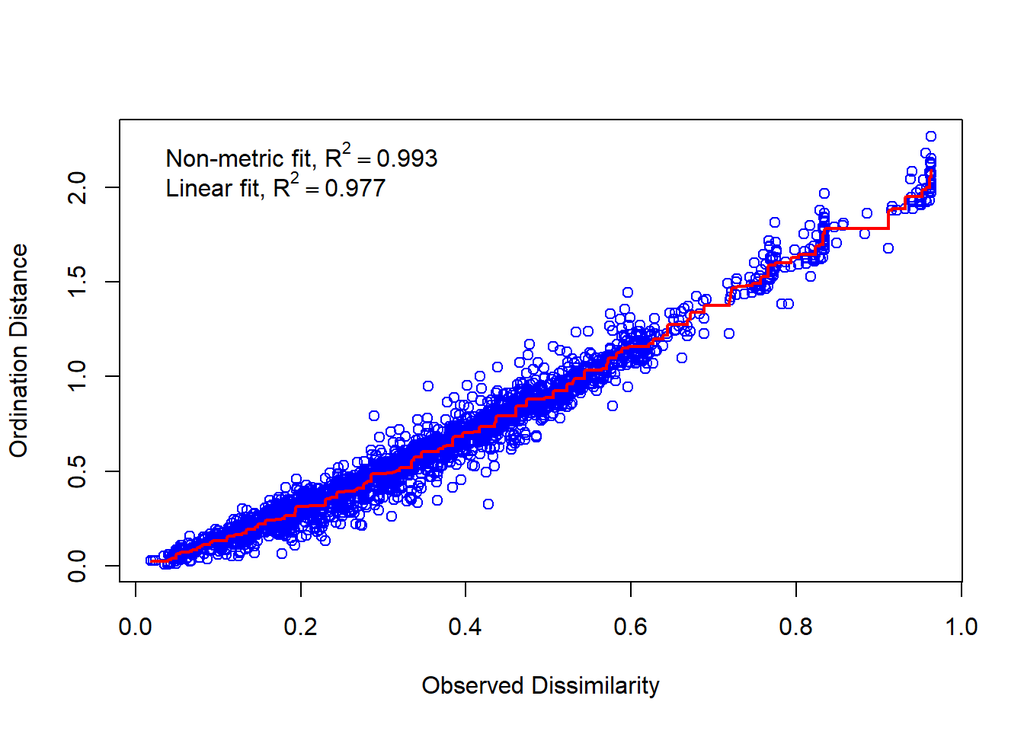

```r
stressplot(cov_nmds_br) #evaluating NMDS mapping: stressplot
```

```r
cov_nmds_br_gof=goodness(cov_nmds_br) #evaluating NMDS mapping: goodness of fit
cov_nmds_br_gof #smaller the value, the lower stress and better fit
```

```
##  [1] 0.010207191 0.007770256 0.007434593 0.007915694 0.005889545 0.006703775
##  [7] 0.014457688 0.006898141 0.005909848 0.007016142 0.006966166 0.019152319
## [13] 0.013748865 0.013879682 0.012297642 0.013204348 0.013336372 0.012385183
## [19] 0.008552310 0.010405323 0.010446426 0.007227061 0.007539408 0.008666996
## [25] 0.010826635 0.010344015 0.014051115 0.007908929 0.006822348 0.009120105
## [31] 0.006806117 0.005737709 0.007716719 0.005665718 0.007050362 0.005703511
## [37] 0.010685927 0.006744443 0.020646664 0.011893429 0.010422738 0.019883814
## [43] 0.006334528 0.007657464 0.007360904 0.021041467 0.014356296 0.012127543
## [49] 0.012072444 0.010257395 0.006176043 0.007361126 0.007139727 0.009614350
## [55] 0.007524368 0.007718481 0.006790863 0.009047887 0.006494318 0.005822469
## [61] 0.005826903 0.007530007 0.006817530 0.006864817 0.007773148 0.008449597
## [67] 0.009095556 0.007730760 0.007362365
```

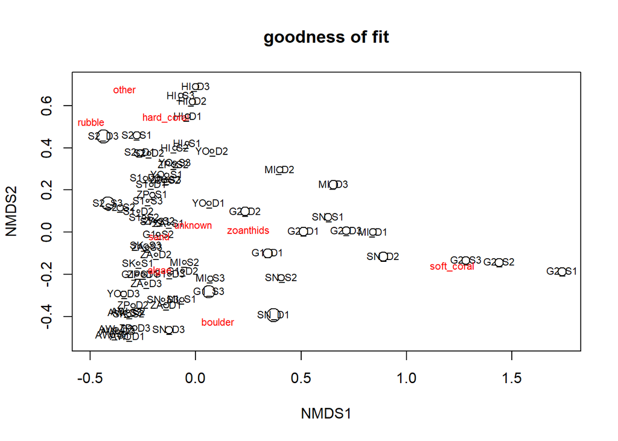

```r
plot(cov_nmds_br, type="t", main="goodness of fit") # create a plot for goodness of fit visualization:
points(cov_nmds_br, display="site", cex=cov_nmds_br_gof*100) #display the goodness of fit on the plot
```

```r
#Stress lesser, better (>0.2 poor,0.2-0.1 moderate,0.1-0.05 good,<0.05 excellent);
#K level higher, stress lesser
cov_nmds_br$stress
```

```
## [1] 0.08365719
```

Stress = 0.0836572 < 0.1, not excellent (<0.05), but still a good ordination

Check Stress for each additional dimension

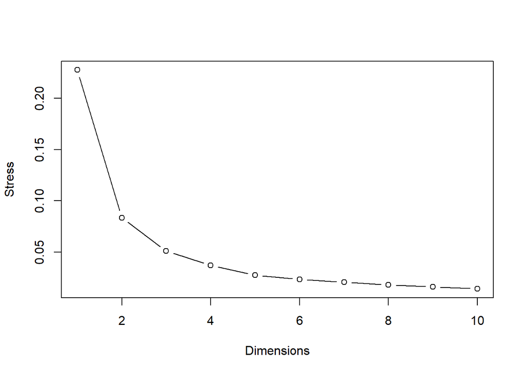

```r
k_vec=1:10
stress=numeric(length(k_vec))
relcov_dij=metaMDSdist(cov_mat, trace=FALSE)
set.seed(69)
for(i in seq_along(k_vec)) {
  cov_nmds_br_loop=metaMDSiter(relcov_dij, k=i, trace=FALSE)
  stress[i]=cov_nmds_br_loop$stress
}
plot(k_vec,stress,type="b",ylab="Stress",xlab="Dimensions") #select the K correspondent to the most drastic drop in stress
```

```r
rm(k_vec)
```

## 2.5 Plot the nMDS with basic R function `plot()`

```r
cov_nmds_br=metaMDS(cov_mat) #Run NMDS
```

```
## *** Best solution repeated 5 times
```

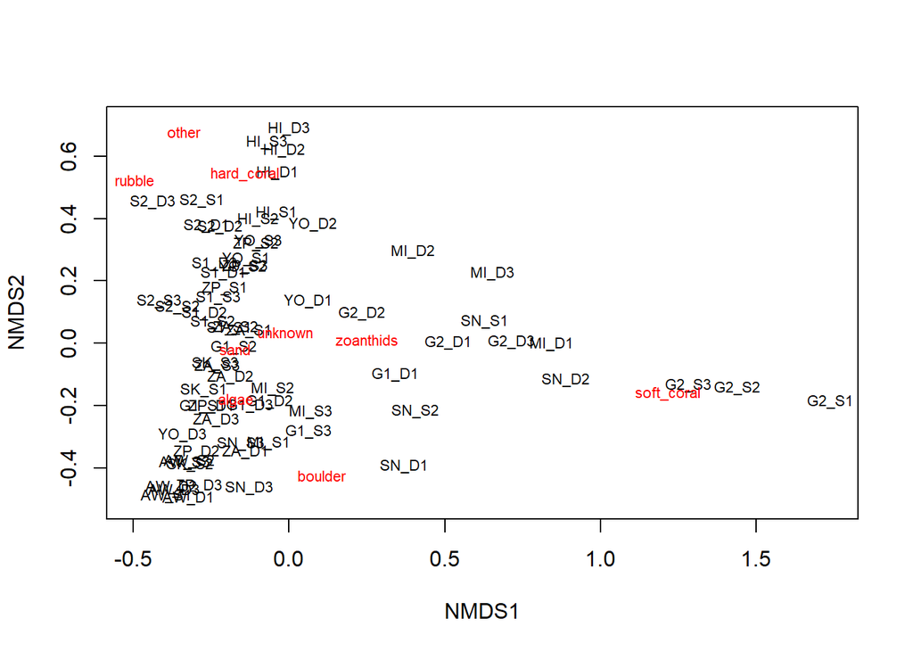

```r
plot(cov_nmds_br, type="text") #NMDS rough plot
```

```r
cov_nmds_br$stress
```

```
## [1] 0.08365719
```

## 2.6 nMDS plot with `ggplot() and` with `geom_mark_ellipse()` from `ggforce`

Create input data frame with nMDS scores necessary for visualisation with `ggplot()`

```r
cov_ndms_scores <- as.data.frame(scores(cov_nmds_br)$sites)  #Using the scores function from vegan to extract the site scores and convert to a data.frame
cov_ndms_scores$transect <- rownames(cov_ndms_scores) # create a column of transect names
cov_ndms_scores$site <- ind_df$Site
cov_ndms_scores$Depth <- ind_df$Depth  #  add the grp variable created earlier
str(cov_ndms_scores)  #look at the data
```

```
## 'data.frame':    69 obs. of  5 variables:
##  $ NMDS1   : num  -0.324 -0.377 -0.37 -0.393 -0.319 ...
##  $ NMDS2   : num  -0.495 -0.462 -0.473 -0.49 -0.377 ...
##  $ transect: chr  "AW_D1" "AW_D2" "AW_D3" "AW_S1" ...
##  $ site    : Ord.factor w/ 12 levels "HI"<"S1"<"S2"<..: 10 10 10 10 10 10 11 11 11 11 ...
##  $ Depth   : Factor w/ 2 levels "Deep","Shallow": 1 1 1 2 2 2 1 1 1 2 ...
```

```r
NMDS1 <- cov_nmds_br$points[,1] ##also found using: > scores(cov_nmds_br)
NMDS2 <- cov_nmds_br$points[,2]
nmds_df<-cbind(ind_df, NMDS1, NMDS2)
rm(NMDS1,NMDS2)
```

nMDS plot

nMDS with ellipses based on the pressure level

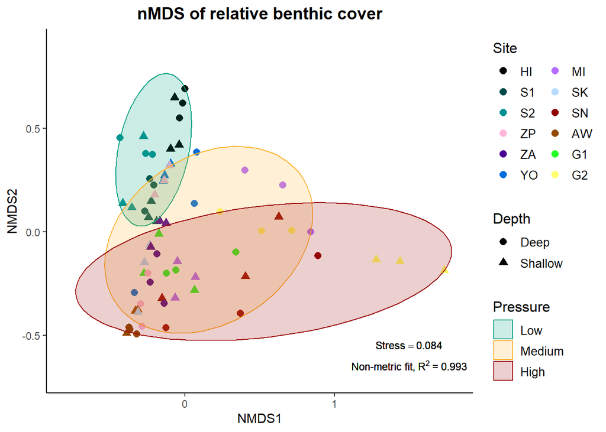

```r
library(ggforce)

pal12 <- c("#000000","#004949","#009292","#ffb6db",
 "#490092","#006ddb","#b66dff","#b6dbff",
 "#920000","#924900","#24ff24","#ffff6d") #Cols from https://stackoverflow.com/questions/65013406/how-to-generate-30-distinct-colors-that-are-color-blind-friendly

library(ggnewscale) #necessary for new_scale_color

ggplot(nmds_df, aes(NMDS1, NMDS2))+
  geom_point(data=nmds_df, aes(NMDS1, NMDS2, color=Site, shape=Depth),size=2.5)+##separates overlapping points
  scale_color_manual(values= pal12)+
  guides(color= guide_legend(order=1, title = "Site", ncol =2))+
  new_scale_color() +
  geom_mark_ellipse(aes(fill=Pressure, color=Pressure), expand = 0, alpha=0.2)+ # https://luisdva.github.io/rstats/Grouping-points/
  scale_color_manual(values= c("#009F81","#FFB331","#9F1111"))+
  scale_fill_manual(values= c("#009F81","#FFB331","#9F1111"))+
  theme_classic()+
  ggtitle("nMDS of relative benthic cover")+
  theme(plot.title = element_text(size=14, face="bold",hjust=.5),
        legend.title = element_text(color = "black", size = 12),
        legend.text = element_text(size=10))+
  scale_x_continuous(limits = c(-.8,1.8))+
  scale_y_continuous(limits = c(-.7,.9))+
  annotate("text", x=1.5, y=-0.6,
           label=bquote(atop(Stress == .(round(cov_nmds_br$stress,3)),
                             'Non-metric fit,'~ R^2~"= 0.993")),
           size=3) #add goodness of fit to plot
```

```r
rm(pal12)
```

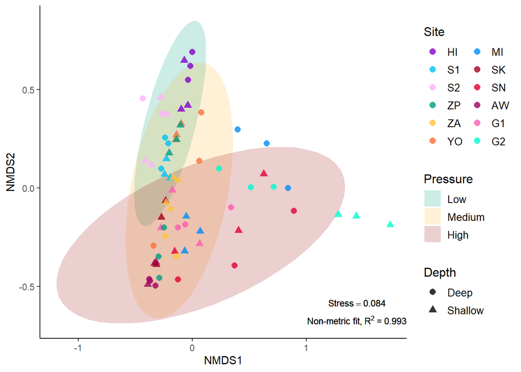

```r
pal_fabian <- c("#8400CD","#00C2F9","#FFB2FD","#009F81","#FFC33B","#FF6E3A","#008DF9","#A40122","#E20134","#9F0162","#FF5AAF","#00FCCF")

ggplot(nmds_df, aes(NMDS1, NMDS2))+
  stat_ellipse(geom = "polygon", aes(fill = Pressure), alpha = 0.2) +
  geom_point(data=nmds_df, aes(NMDS1, NMDS2, color=Site, shape=Depth),size=2.5, alpha = 0.8)+##separates overlapping points+
  scale_fill_manual(values= c("#009F81", "#FFB331","#9F1111"))+
  scale_color_manual(values= pal_fabian)+
  labs(x = "NMDS1", colour = "Site", y = "NMDS2") +
  guides(color= guide_legend(order=1, title = "Site", ncol =2),
         fill=guide_legend(order=2))+
  theme_classic()+
  theme(plot.title = element_text(size=14, face="bold",hjust=.5),
        legend.title = element_text(color = "black", size = 12),
        legend.text = element_text(size=10))+
    annotate("text", x=Inf, y=-Inf, hjust = 1, vjust = -0.5,
           label=bquote(atop(Stress == .(round(cov_nmds_br$stress,3)),
                             'Non-metric fit,'~ R^2~"= 0.993")),
           size=3) #add goodness of fit to plot
```

```r
ggsave("ndms_relcov_pressure.tiff",
       units ="in", width = 5, height = 5, dpi = 300, compression = 'lzw',
       path = here("Multi-taxa_data","PLITs","4-Visualization_outputs"))

ggsave("ndms_relcov_pressure.png",
       units ="in", width = 5, height = 5, dpi = 300,
       path = here("Multi-taxa_data","PLITs","4-Visualization_outputs"))
```

# 3 MANTEL TEST

```r
library(fields)
library(reshape2)
library(ade4)
library(adespatial)
library(spdep)
```

```r
library(ggplot2)
```

Load distance file and create distance matrix

```r
Ok_dist_69 <- read.csv(file=here("Multi-taxa_data","Ok_dist_69.csv"), row.names=1 )
head(Ok_dist_69)
```

```
##                  Long      Lat
## AW_deep_1    127.9136 26.60075
## AW_deep_2    127.9136 26.60075
## AW_deep_3    127.9136 26.60075
## AW_shallow_1 127.9136 26.60075
## AW_shallow_2 127.9136 26.60075
## AW_shallow_3 127.9136 26.60075
```

```r
Dist_km <- as.dist(rdist.earth(Ok_dist_69, miles=F))

cov_bray <- vegdist(cov_mat, method = "bray")
```

Correlation between straight-line geographic distance and dissimilarity in species composition

```r
set.seed(69)
mantel(Dist_km, cov_bray)
```

```
##
## Mantel statistic based on Pearson's product-moment correlation
##
## Call:
## mantel(xdis = Dist_km, ydis = cov_bray)
##
## Mantel statistic r: 0.01271
##       Significance: 0.383
##
## Upper quantiles of permutations (null model):
##    90%    95%  97.5%    99%
## 0.0692 0.0955 0.1146 0.1326
## Permutation: free
## Number of permutations: 999
```

Plot

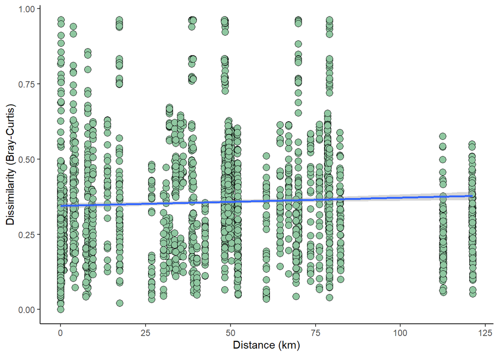

```r
cov_matrix_dist <- data.frame(x = melt(as.matrix(Dist_km))$value,
                          y = melt(as.matrix(cov_bray))$value) ## Prepare data for graphic

ggplot(cov_matrix_dist) +
  geom_jitter( aes(x,y), shape = 21, size = 3, fill = "#8fc7a0") +
  labs(x = "Distance (km)",
       y = "Dissimilarity (Bray-Curtis)") +
  geom_smooth( aes(x,y), method = "glm") +
  theme_classic()
```

```r
ggsave("cov_dissimil_distance.tiff",
       units="in", width=6, height=4, dpi=300, compression = 'lzw',
       path = here ("Multi-taxa_data","PLITs","4-Visualization_outputs"))

ggsave("cov_dissimil_distance.png",
       units="in", width=6, height=4, dpi=300,
       path = here ("Multi-taxa_data","PLITs","4-Visualization_outputs"))
```

## 3.1 Mantel

```r
set.seed(69)
mantel_cov <- mantel.randtest(cov_bray, Dist_km)
mantel_cov
```

```
## Monte-Carlo test
## Call: mantel.randtest(m1 = cov_bray, m2 = Dist_km)
##
## Observation: 0.01271356
##
## Based on 999 replicates
## Simulated p-value: 0.385
## Alternative hypothesis: greater
##
##      Std.Obs  Expectation     Variance
## 0.2310350804 0.0007376201 0.0026869714
```

# 4 BOXPLOTS FOR INGROUP VARIANCE

Load libraries

```r
#VEGAN----
library(vegan)#load package
library(MASS)
library(dplyr)
library(readxl)   # to import excel datasets
library(here)
```

Load and format data

```r
#Relative benthic cover dataframe

cov_df <- read_excel(here("Multi-taxa_data","PLITs","3-Clean_data","Rel_cov_input.xlsx"))
str(cov_df)
```

```
## tibble [69 × 24] (S3: tbl_df/tbl/data.frame)
##  $ Transect  : chr [1:69] "AW_D1" "AW_D2" "AW_D3" "AW_S1" ...
##  $ Site      : chr [1:69] "AW" "AW" "AW" "AW" ...
##  $ Depth_rep : chr [1:69] "D1" "D2" "D3" "S1" ...
##  $ depth     : chr [1:69] "Deep" "Deep" "Deep" "Shallow" ...
##  $ Site_depth: chr [1:69] "AW_Deep" "AW_Deep" "AW_Deep" "AW_Shallow" ...
##  $ Replicate : chr [1:69] "1" "2" "3" "1" ...
##  $ algae     : num [1:69] 0.85 0.92 0.934 0.953 0.874 0.899 0.497 0.691 0.734 0.8 ...
##  $ boulder   : num [1:69] 0.018 0 0.01 0 0.023 0 0 0 0 0 ...
##  $ hard_coral: num [1:69] 0 0.018 0.026 0.023 0.073 0.075 0.104 0.143 0.152 0.167 ...
##  $ other     : num [1:69] 0 0.001 0 0 0 0 0 0 0 0 ...
##  $ rubble    : num [1:69] 0.059 0.004 0.014 0.019 0.001 0.01 0.005 0.012 0 0 ...
##  $ sand      : num [1:69] 0.047 0.042 0.006 0.003 0.024 0.008 0.096 0.036 0.014 0 ...
##  $ soft_coral: num [1:69] 0.023 0.001 0 0 0.001 0.002 0.276 0.107 0.077 0 ...
##  $ unknown   : num [1:69] 0.003 0.014 0.009 0.001 0.004 0.003 0.023 0.01 0.024 0.033 ...
##  $ zoanthids : num [1:69] 0 0 0 0 0 0.003 0 0 0 0 ...
##  $ sd_alg    : num [1:69] 0.05 0.05 0.05 0.04 0.04 0.04 0.13 0.13 0.13 0.1 ...
##  $ sd_boulder: num [1:69] 0.01 0.01 0.01 0.01 0.01 0.01 0 0 0 0 ...
##  $ sd_hc     : num [1:69] 0.01 0.01 0.01 0.03 0.03 0.03 0.03 0.03 0.03 0.08 ...
##  $ sd_other  : num [1:69] 0 0 0 0 0 0 0 0 0 0 ...
##  $ sd_rubble : num [1:69] 0.03 0.03 0.03 0.01 0.01 0.01 0.01 0.01 0.01 0 ...
##  $ sd_sand   : num [1:69] 0.02 0.02 0.02 0.01 0.01 0.01 0.04 0.04 0.04 0 ...
##  $ sd_softc  : num [1:69] 0.01 0.01 0.01 0 0 0 0.11 0.11 0.11 0.03 ...
##  $ sd_unknown: num [1:69] 0.01 0.01 0.01 0 0 0 0.01 0.01 0.01 0.01 ...
##  $ sd_zoanth : num [1:69] 0 0 0 0 0 0 0 0 0 0.12 ...
```

```r
cov_df <- cov_df %>%
  mutate(Pressure = case_when(Site == 'HI' |
                              Site == "S1" |
                              Site == "S2" ~ "Low",
                              Site == "ZP" |
                              Site == 'ZA' |
                              Site == "YO" |
                              Site == "MI" ~ "Medium",
                              Site == 'SK' |
                              Site == 'SN' |
                              Site == "AW" |
                              Site == "G1" |
                              Site == "G2"~ "High")) %>%
  rename(Depth = depth)

cov_df <- cov_df[ ,c(1:6, 25, 7:24)]

cov_df$Site<-ordered(cov_df$Site,levels=c("HI", "S1", "S2", "ZP", "ZA", "YO", "MI","SK", "SN", "AW", "G1", "G2"))

cov_df$Pressure<-ordered(cov_df$Pressure,levels=c("Low", "Medium", "High"))

cov_df[,c(1,3:6)] <- lapply(cov_df[,c(1,3:6)], as.factor)  ## as.factor() could also be used

cov_df[,8:25] <- lapply(cov_df[,8:25], as.numeric)

cov_df <- cov_df[,-c(17:25)]

str(cov_df)
```

```
## tibble [69 × 16] (S3: tbl_df/tbl/data.frame)
##  $ Transect  : Factor w/ 69 levels "AW_D1","AW_D2",..: 1 2 3 4 5 6 7 8 9 10 ...
##  $ Site      : Ord.factor w/ 12 levels "HI"<"S1"<"S2"<..: 10 10 10 10 10 10 11 11 11 11 ...
##  $ Depth_rep : Factor w/ 6 levels "D1","D2","D3",..: 1 2 3 4 5 6 1 2 3 4 ...
##  $ Depth     : Factor w/ 2 levels "Deep","Shallow": 1 1 1 2 2 2 1 1 1 2 ...
##  $ Site_depth: Factor w/ 23 levels "AW_Deep","AW_Shallow",..: 1 1 1 2 2 2 3 3 3 4 ...
##  $ Replicate : Factor w/ 3 levels "1","2","3": 1 2 3 1 2 3 1 2 3 1 ...
##  $ Pressure  : Ord.factor w/ 3 levels "Low"<"Medium"<..: 3 3 3 3 3 3 3 3 3 3 ...
##  $ algae     : num [1:69] 0.85 0.92 0.934 0.953 0.874 0.899 0.497 0.691 0.734 0.8 ...
##  $ boulder   : num [1:69] 0.018 0 0.01 0 0.023 0 0 0 0 0 ...
##  $ hard_coral: num [1:69] 0 0.018 0.026 0.023 0.073 0.075 0.104 0.143 0.152 0.167 ...
##  $ other     : num [1:69] 0 0.001 0 0 0 0 0 0 0 0 ...
##  $ rubble    : num [1:69] 0.059 0.004 0.014 0.019 0.001 0.01 0.005 0.012 0 0 ...
##  $ sand      : num [1:69] 0.047 0.042 0.006 0.003 0.024 0.008 0.096 0.036 0.014 0 ...
##  $ soft_coral: num [1:69] 0.023 0.001 0 0 0.001 0.002 0.276 0.107 0.077 0 ...
##  $ unknown   : num [1:69] 0.003 0.014 0.009 0.001 0.004 0.003 0.023 0.01 0.024 0.033 ...
##  $ zoanthids : num [1:69] 0 0 0 0 0 0.003 0 0 0 0 ...
```

```r
#create a df with the independent variables
ind_df <- as.data.frame(cov_df[,c(1:7)])
str(ind_df)
```

```
## 'data.frame':    69 obs. of  7 variables:
##  $ Transect  : Factor w/ 69 levels "AW_D1","AW_D2",..: 1 2 3 4 5 6 7 8 9 10 ...
##  $ Site      : Ord.factor w/ 12 levels "HI"<"S1"<"S2"<..: 10 10 10 10 10 10 11 11 11 11 ...
##  $ Depth_rep : Factor w/ 6 levels "D1","D2","D3",..: 1 2 3 4 5 6 1 2 3 4 ...
##  $ Depth     : Factor w/ 2 levels "Deep","Shallow": 1 1 1 2 2 2 1 1 1 2 ...
##  $ Site_depth: Factor w/ 23 levels "AW_Deep","AW_Shallow",..: 1 1 1 2 2 2 3 3 3 4 ...
##  $ Replicate : Factor w/ 3 levels "1","2","3": 1 2 3 1 2 3 1 2 3 1 ...
##  $ Pressure  : Ord.factor w/ 3 levels "Low"<"Medium"<..: 3 3 3 3 3 3 3 3 3 3 ...
```

Convert the database `cov_df`to a matrix

```r
cov_mat <- cov_df[,-c(1:7)]
rownames(cov_mat) <- cov_df$Transect
cov_mat <- as.matrix(cov_mat)
str(cov_mat)
```

```
##  num [1:69, 1:9] 0.85 0.92 0.934 0.953 0.874 0.899 0.497 0.691 0.734 0.8 ...
##  - attr(*, "dimnames")=List of 2
##   ..$ : chr [1:69] "AW_D1" "AW_D2" "AW_D3" "AW_S1" ...
##   ..$ : chr [1:9] "algae" "boulder" "hard_coral" "other" ...
```

```r
class(cov_mat)
```

```
## [1] "matrix" "array"
```

Create a df with explanatory (independent) variables

```r
ind_df <- as.data.frame(cov_df[,c(1:7)])
str(ind_df)
```

```
## 'data.frame':    69 obs. of  7 variables:
##  $ Transect  : Factor w/ 69 levels "AW_D1","AW_D2",..: 1 2 3 4 5 6 7 8 9 10 ...
##  $ Site      : Ord.factor w/ 12 levels "HI"<"S1"<"S2"<..: 10 10 10 10 10 10 11 11 11 11 ...
##  $ Depth_rep : Factor w/ 6 levels "D1","D2","D3",..: 1 2 3 4 5 6 1 2 3 4 ...
##  $ Depth     : Factor w/ 2 levels "Deep","Shallow": 1 1 1 2 2 2 1 1 1 2 ...
##  $ Site_depth: Factor w/ 23 levels "AW_Deep","AW_Shallow",..: 1 1 1 2 2 2 3 3 3 4 ...
##  $ Replicate : Factor w/ 3 levels "1","2","3": 1 2 3 1 2 3 1 2 3 1 ...
##  $ Pressure  : Ord.factor w/ 3 levels "Low"<"Medium"<..: 3 3 3 3 3 3 3 3 3 3 ...
```